# Hypoxic, Eutrophic & OA map

Compiled on Wed Jul 10 14:53:25 2019 by afflerbach

## Summary

This script creates a map showing regions of the world where acidic conditions exist (aragonite saturation state <= 3), along with specific sites identified as either Eutrophic or Hypoxic. At the end of this script, multiple statistics are run to glean information about countries that are suitable for seaweed farming. For example, how many countries that have been identified as suitable for seaweed farming are also experiencing hypoxic, eutrophic AND acidic conditions? (Hint it’s 24).

## Setup

```r
knitr::opts_chunk$set(echo = TRUE, message = F, warning = F)

library(tidyverse)
library(sf)
library(raster)
library(tmap)
library(RColorBrewer)
library(readxl)

#point to aquaculture folder on aurora
dir_a <- c('Windows' = '//aurora.nceas.ucsb.edu/aquaculture',
           'Darwin'  = '/Volumes/aquaculture',
           'Linux'   = '/home/shares/aquaculture')[[ Sys.info()[['sysname']] ]]

#set rainbow color scheme
cols      = colorRampPalette(brewer.pal(9, 'Spectral'))(255) # rainbow color scheme
```

## Data cleaning

### Hypoxic/eutrophic data

Read in hypoxic eutrophic site data

```r
sites <- read_excel("~/github/seaweed/Data/wri_eutrophic_hypoxic_dataset_2011-03.xls")

#filter for only eutrophic and hypoxic sites
sites_he <- sites %>%
  mutate(category = ifelse(Classification == "eutrophic", "Eutrophic", Classification)) %>%
  filter(!category %in% c("Improved", "improved"))
```

Create `sf` object from sites

```r
sites_sf <- st_as_sf(sites_he,coords = c("Long", "Lat"), crs = 4326)
```

### Ocean Acidification

Load OA raster, interpolate to gapfill missing cells especially at the Arctic, and then remove all cells with Aragonite saturation state greater than 3

```r
#load OA raster from 2016
oa    <- raster(file.path(dir_a, "ARF/oa/global_arag_avg_moll_2016.tif"))
ocean <- raster(file.path(dir_a, "ARF/oa/ocean.tif")) %>% #ocean raster at 1km to use as a mask on the OA data
           resample(oa)

#interpolate across NA
xy <- data.frame(xyFromCell(oa, 1:ncell(oa)))                         #get xy coords into dataframe
v  <- getValues(oa)                                                   #get cell values
tmpdf <- cbind(xy, v)%>%filter(!is.na(v))                             #create dataframe of x,y, and values. remove NAs (throws error since these are cells we are interpolating over)
mg <- gstat::gstat(id = "v", formula = v~1, locations = ~x+y, data=tmpdf,
            nmax=7, set=list(idp = 2)) #define model. power function = 2, this is default for idw models
oa_int <- interpolate(oa, mg, progress='text')
```

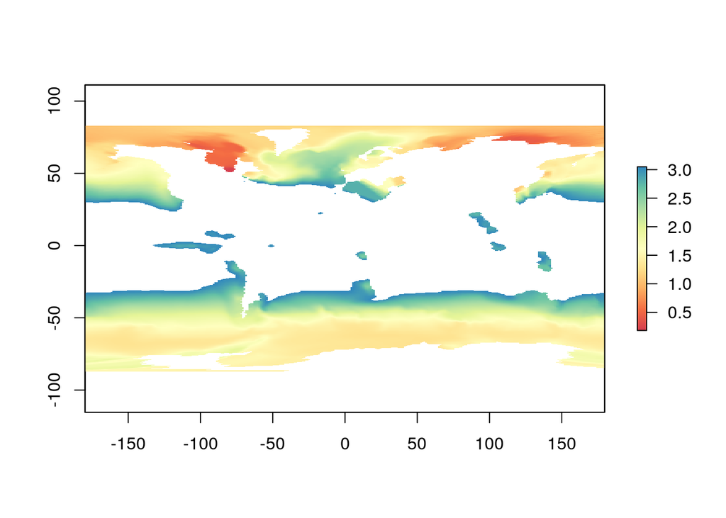

```r
oa_mask <- mask(oa_int, ocean)

oa_mask[oa_mask>3.05]<-NA #using 3.05 to get contour lines for Aragonite values at 3

oa_wgs <- projectRaster(oa_mask, crs = "+proj=longlat +datum=WGS84 +no_defs")
plot(oa_wgs, col = cols)
```

## Make map

### Get world map

```r
#grab the worldmap from rnaturalearth
worldmap <- rnaturalearth::ne_download(scale = 110,
                                       type = "countries",
                                       category = "cultural",
                                       destdir = tempdir(),
                                       load = TRUE,
                                       returnclass = "sf")
```

### Final map and save

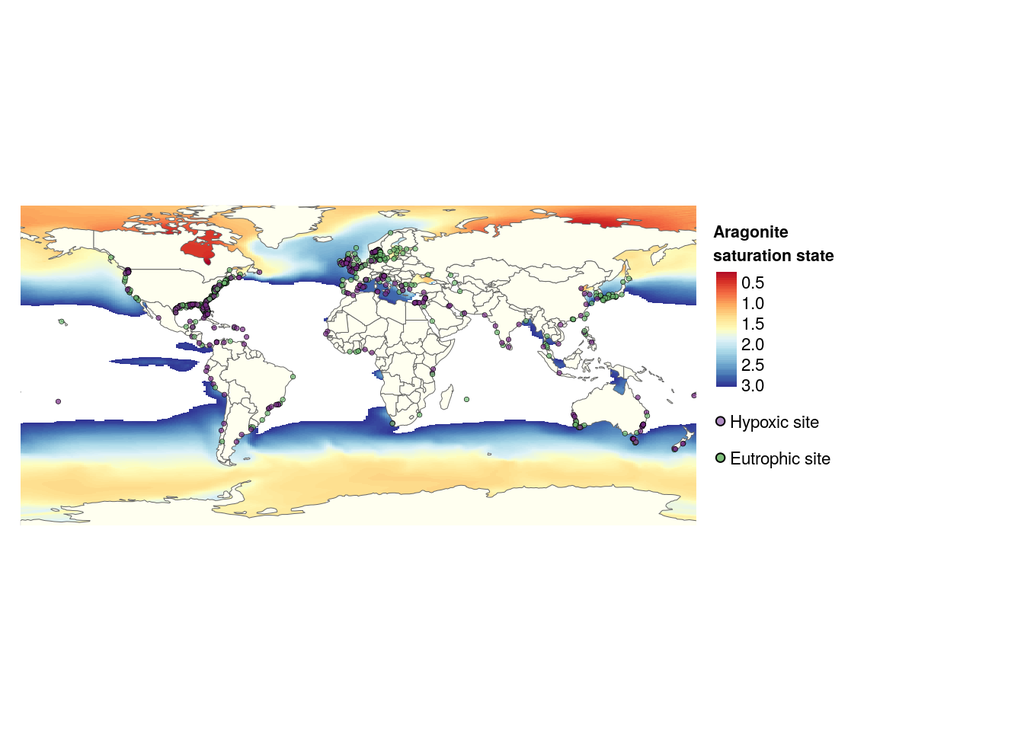

```r
#make map
hyp_eut_map <-
  tm_shape(oa_wgs) +
  tm_raster(palette = "RdYlBu", style = "cont", title = "Aragonite \nsaturation state") +
  # tm_shape(oa_cont) +
  # tm_lines() +
  tm_shape(worldmap) +
  tm_polygons(col = "ivory", lwd = 0.5) +
  tm_shape(sites_sf) +
  tm_symbols(col = "category", border.col = "black", border.lwd = 0.3,
             size = 0.05, alpha = 0.7, title.col = " ", palette = "PRGn", legend.col.show = FALSE) +
  tm_legend(outside = TRUE) +
  tm_add_legend(type = "symbol", shape = 21, labels = "Hypoxic site", col = "#AF8DC3", size = 0.4) +
  tm_add_legend(type = "symbol", shape = 21, labels = "Eutrophic site", col = "#7FBF7B", size = 0.4) +
  tm_layout(legend.title.size = 0.8, legend.title.fontface = "bold", frame = F)


tmap_save(hyp_eut_map, filename = "../Figs/hyp_eut_map.pdf", width = 6, height = 2.5, units = "in")

hyp_eut_map
```

## Get country specific statistics

Get list of countries that have hypoxic, eutrophic and/or acidic conditions.

```r
#suitable countries for seaweed
ctrys <- read_csv("~/github/seaweed/Data/sw_feasible_countries.csv")

#reading in the OHI EEZ shapefile from aurora and filtering just for EEZs while removing Antarctica
eezs <- read_sf(file.path(dir_a, "input/world_eezs/regions_2017_update.shp"), quiet = T)

#intersect the sites with eezs
sites_moll <- sites_sf %>%
  st_transform(crs = "+proj=moll +lon_0=0 +x_0=0 +y_0=0 +datum=WGS84 +units=m +no_defs")

sites_int <- st_intersection(eezs, sites_moll)
st_set_geometry(sites_int, NULL)
```

```
## # A tibble: 720 x 22
##    type_w_ant rgn_type rgn_id rgn_name rgn_key rgn_ant_id area_km2    ID
##  * <chr>      <chr>     <int> <chr>    <chr>        <int>    <dbl> <dbl>
##  1 eez        eez         120 Antigua… ATG            120   108492     2
##  2 eez        eez          16 Austral… AUS             16  6956846     4
##  3 land       land         16 Austral… AUS             16  7721726     5
##  4 land       land         16 Austral… AUS             16  7721726     7
##  5 eez        eez          16 Austral… AUS             16  6956846     8
##  6 land       land         16 Austral… AUS             16  7721726     9
##  7 eez        eez          16 Austral… AUS             16  6956846    10
##  8 eez        eez          16 Austral… AUS             16  6956846    13
##  9 land       land         16 Austral… AUS             16  7721726    14
## 10 land       land         16 Austral… AUS             16  7721726    15
## # … with 710 more rows, and 14 more variables: System <chr>,
## #   Country <chr>, Decade <dbl>, Hypoxia.Current <chr>, Benthic <chr>,
## #   Fisheries <chr>, Comment <chr>, References <chr>,
## #   Classification <chr>, Photo.Notes <chr>, Video.Link <chr>,
## #   YouTube.ID <chr>, ...16 <chr>, category <chr>
```

```r
#get the columns we want (country, classification, site info)
si <- sites_int %>%
  dplyr::select(rgn_name, System, Country, Classification)


#dataframe that lists each country, and how many sites are eutrophic or hypoxic within each, filtered for feasible countries
ctrys_w_eut_hyp <- si %>%
  mutate(Classification = ifelse(Classification == "eutrophic", "Eutrophic", Classification)) %>%
  group_by(rgn_name) %>%
  add_count(Classification) %>%
  dplyr::select(rgn_name, Classification, n) %>%
  distinct() %>%
  filter(rgn_name %in% ctrys$country)
```

Get list of countries that have acidic conditions (aragonite saturation state < 3)

```r
#overlay EEZ shapefile on our masked out OA layer to get countries with cells w/ acidic conditions
oa_ctrys <- extract(oa_mask, eezs, df = TRUE)

#remove NA cells and match up IDs
oa_ctry <- oa_ctrys %>%
  filter(!is.na(x))

#grab IDs from the extract data frame
ctry_ids <- unique(oa_ctry$ID)

#create a column in eezs that is equivalent to the rownames (which are the IDs returned from extract)
eezs$IDs <- row.names(eezs)

st_geometry(eezs) <- NULL

#see what countries those are from eezs
a <- eezs %>%
  filter(IDs %in% ctry_ids)

#get final list of countries w/ acidic conditions
final_oa_countries <- a %>%
  filter(rgn_type != "fao") %>%
  dplyr::select(rgn_name) %>%
  distinct() %>%
  filter(rgn_name %in% ctrys$country)
```

Now we combine the hypoxic/eutrophic dataframe with the ocean acidification one

```r
b <- ctrys_w_eut_hyp %>%
  bind_rows(final_oa_countries) %>% #add in the OA countries
  mutate(Classification = ifelse(is.na(Classification), "oa", Classification),
         n = ifelse(Classification == "oa", 1, n)) %>%
  spread(key = Classification, value = n) %>%
  mutate(OA = ifelse(rgn_name %in% final_oa_countries$rgn_name, 1, 0),
         Eutrophic = ifelse(!is.na(Eutrophic), 1, 0),
         Hypoxic = ifelse(!is.na(Hypoxic), 1, 0)) %>%
  dplyr::select(-oa) %>%
  mutate(sum = sum(OA, Eutrophic, Hypoxic))

write.csv(b, file = "~/github/seaweed/Data/countries_w_hyp_eut_oa_conditions.csv")
```

## Additional statistics

How many countries have acidic conditions?

```r
b %>%
  filter(OA == 1) %>%
  nrow()
```

```
## [1] 77
```

These countries have all three conditions

```r
b %>% filter(sum == 3) %>% .$rgn_name
```

```
##  [1] "Australia"      "Brazil"         "Canada"         "Chile"
##  [5] "China"          "Colombia"       "Costa Rica"     "Croatia"
##  [9] "France"         "Germany"        "Greece"         "India"
## [13] "Ireland"        "Italy"          "Mexico"         "New Zealand"
## [17] "Norway"         "Peru"           "South Africa"   "South Korea"
## [21] "Spain"          "Turkey"         "United Kingdom" "United States"
```

Number of feasible countries with Eutrophic conditions

```r
b %>% filter(Eutrophic==1) %>% nrow()
```

```
## [1] 44
```

Number of feasible countries with Hypoxic conditions

```r
b %>% filter(Hypoxic == 1) %>% nrow()
```

```
## [1] 44
```

Number of feasible countries with Eutrophic and Hypoxic

```r
b %>% filter(Eutrophic == 1 & Hypoxic == 1) %>% nrow()
```

```
## [1] 27
```